# Gaussian Processes: Introduction

[JuliaGPs](https://github.com/JuliaGaussianProcesses/#welcome-to-juliagps) packages integrate well with Turing.jl because they implement the Distributions.jl interface. This tutorial assumes basic knowledge of [Gaussian processes](https://en.wikipedia.org/wiki/Gaussian_process) (i.e., a general understanding of what they are); for a comprehensive introduction, see [Rasmussen and Williams (2006)](http://www.gaussianprocess.org/gpml/). For a more in-depth understanding of the [JuliaGPs](https://github.com/JuliaGaussianProcesses/#welcome-to-juliagps) functionality used here, please consult the [JuliaGPs](https://github.com/JuliaGaussianProcesses/#welcome-to-juliagps) docs.

In this tutorial, we will model the putting dataset discussed in Chapter 21 of [Bayesian Data Analysis](http://www.stat.columbia.edu/%7Egelman/book/). The dataset comprises the result of measuring how often a golfer successfully gets the ball in the hole, depending on how far away from it they are. The goal of inference is to estimate the probability of any given shot being successful at a given distance.

### Let’s download the data and take a look at it:

```julia
using CSV, DataFrames

df = CSV.read("golf.dat", DataFrame; delim=' ', ignorerepeated=true)
df[1:5, :]
```

5×3 DataFrame

| Row | distance Int64 | n Int64 | y Int64 |
| --- | --- | --- | --- |
| 1 | 2 | 1443 | 1346 |
| 2 | 3 | 694 | 577 |
| 3 | 4 | 455 | 337 |
| 4 | 5 | 353 | 208 |
| 5 | 6 | 272 | 149 |

These are the first 5 rows of the dataset (which comprises only 19 rows in total). Observe it has three columns:

1. `distance` – how far away from the hole. We will refer to `distance` as `d` throughout the rest of this tutorial
2. `n` – how many shots were taken from a given distance
3. `y` – how many shots were successful from a given distance

We will use a Binomial model for the data, whose success probability is parametrised by a transformation of a GP. Something along the lines of:

$$\begin{aligned}
f & \sim \operatorname{GP}(0, k) \\
y_j \mid f(d_j) & \sim \operatorname{Binomial}(n_j, g(f(d_j))) \\
g(x) & := \frac{1}{1 + e^{-x}}
\end{aligned}$$

To do this, let’s define our Turing.jl model:

```julia
using AbstractGPs, LogExpFunctions, Turing

@model function putting_model(d, n; jitter=1e-4)
    v ~ Gamma(2, 1)
    l ~ Gamma(4, 1)
    f = GP(v * with_lengthscale(SEKernel(), l))
    f_latent ~ f(d, jitter)
    y ~ product_distribution(Binomial.(n, logistic.(f_latent)))
    return (fx=f(d, jitter), f_latent=f_latent, y=y)
end
```

```
putting_model (generic function with 2 methods)
```

We first define an `AbstractGPs.GP`, which represents a distribution over functions, and is entirely separate from Turing.jl. We place a prior over its variance `v` and length-scale `l`. `f(d, jitter)` constructs the multivariate Gaussian comprising the random variables in `f` whose indices are in `d` (plus a bit of independent Gaussian noise with variance `jitter` – see [the docs](https://juliagaussianprocesses.github.io/AbstractGPs.jl/dev/api/#FiniteGP-and-AbstractGP) for more details). `f(d, jitter)` has the type `AbstractMvNormal`, and is the bit of AbstractGPs.jl that implements the Distributions.jl interface, so it’s legal to put it on the right-hand side of a `~`. From this you should deduce that `f_latent` is distributed according to a multivariate Gaussian. The remaining lines comprise standard Turing.jl code that is encountered in other tutorials and Turing documentation.

Before performing inference, we might want to inspect the prior that our model places over the data, to see whether there is anything obviously wrong. These kinds of prior predictive checks are straightforward to perform using Turing.jl, since it is possible to sample from the prior easily by just calling the model:

```julia
m = putting_model(Float64.(df.distance), df.n)
m().y
```

```
19-element Vector{Int64}:
 1227
  611
  403
  295
  231
  222
  213
  194
  163
  187
  144
  136
  129
  115
  132
  117
  127
  102
  101
```

We make use of this to see what kinds of datasets we simulate from the prior:

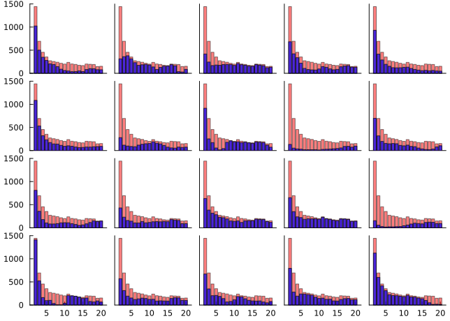

```julia
using Plots

function plot_data(d, n, y, xticks, yticks)
    ylims = (0, round(maximum(n), RoundUp; sigdigits=2))
    margin = -0.5 * Plots.mm
    plt = plot(; xticks=xticks, yticks=yticks, ylims=ylims, margin=margin, grid=false)
    bar!(plt, d, n; color=:red, label="", alpha=0.5)
    bar!(plt, d, y; label="", color=:blue, alpha=0.7)
    return plt
end

# Construct model and run some prior predictive checks.
m = putting_model(Float64.(df.distance), df.n)
hists = map(1:20) do j
    xticks = j > 15 ? :auto : nothing
    yticks = rem(j, 5) == 1 ? :auto : nothing
    return plot_data(df.distance, df.n, m().y, xticks, yticks)
end
plot(hists...; layout=(4, 5))
```

In this case, the only prior knowledge we is that the proportion of successful shots ought to decrease monotonically as the distance from the hole increases, which should show up in the data as the blue lines generally go down as we move from left to right on each graph. Unfortunately, there is not a simple way to enforce monotonicity in the samples from a GP, and we can see this in some of the plots above, so we must hope that we have enough data to ensure that this relationship holds approximately under the posterior. In any case, you can judge for yourself whether you think this is the most useful visualisation that we can perform; if you think there is something better to look at, please let us know!

Moving on, we generate samples from the posterior using the default `NUTS` sampler. We’ll make use of Mooncake.jl, as it has better performance than [ForwardDiff.jl](https://github.com/JuliaDiff/ForwardDiff.jl/) on this example. See the automatic differentiation docs for more info.

```julia
using Random
using Mooncake: Mooncake

m_post = m | (y=df.y,)
# Note that the struct `AutoMooncake()` is a very small struct
# defined in ADTypes.jl, which just means 'attempt to use
# Mooncake.jl for automatic differentiation'. This struct is
# reexported by Turing. However, you must also import
# Mooncake itself which allows the AD call to execute.
chn = sample(Xoshiro(123456), m_post, NUTS(; adtype=AutoMooncake()), 1_000, progress=false)
```

```
┌ Info: Found initial step size
└   ϵ = 0.2
┌ Warning: There were 1 divergent transitions. Consider reparameterising your model or using a smaller step size. For adaptive samplers such as NUTS and HMCDA, consider increasing `target_accept`.
└ @ Turing.Inference ~/.julia/packages/Turing/WteH7/src/mcmc/hmc.jl:483
```

```
╭─FlexiChain (1000 iterations, 1 chain) ───────────────────────────────────────╮
│ ↓ iter  = 501:1500                                                           │
│ → chain = 1:1                                                                │
│                                                                              │
│ Parameters (3) ── AbstractPPL.VarName                                        │
│  Float64          v, l                                                       │
│  Vector{Float64}  f_latent (19,)                                             │
│                                                                              │
│ Extras (14)                                                                  │
│  Int64    n_steps, tree_depth                                                │
│  Bool     is_accept, numerical_error                                         │
│  Float64  acceptance_rate, log_density, hamiltonian_energy,                  │
│           hamiltonian_energy_error, max_hamiltonian_energy_error, step_size, │
│           nom_step_size, logprior, loglikelihood, logjoint                   │
╰──────────────────────────────────────────────────────────────────────────────╯
```

We can use these samples and the `posterior` function from `AbstractGPs` to sample from the posterior probability of success at any distance we choose:

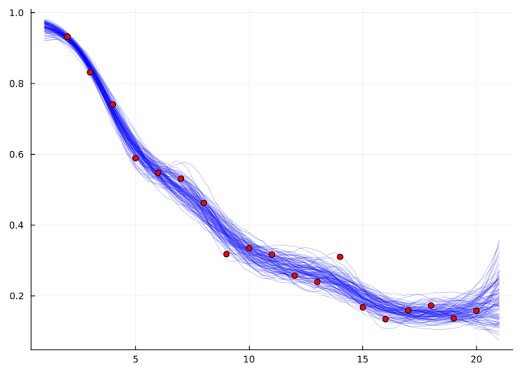

```julia
d_pred = 1:0.2:21
samples = map(returned(m_post, chn)[1:10:end]) do x
    return logistic.(rand(posterior(x.fx, x.f_latent)(d_pred, 1e-4)))
end
p = plot()
plot!(d_pred, reduce(hcat, samples); label="", color=:blue, alpha=0.2)
scatter!(df.distance, df.y ./ df.n; label="", color=:red)
```

We can see that the general trend is indeed down as the distance from the hole increases, and that if we move away from the data, the posterior uncertainty quickly inflates. This suggests that the model is probably going to do a reasonable job of interpolating between observed data, but less good a job at extrapolating to larger distances.

Back to top